# Lunden | Duration, vowel quality, and the rhythmic pattern of English | Laboratory Phonology

[figure not shown]

Journal article  
Duration, vowel quality, and the rhythmic pattern of English

## Abstract

Languages with binary stress systems frequently tolerate a stress lapse over the final two syllables, but almost none tolerate a word-initial stress lapse. Lunden (to appear) argues that this lapse asymmetry can be explained by the presence of word-level final lengthening, which can then create the perception of prominence alternation in languages that use duration as stress correlate. The results of a production and a perception study with English speakers are presented which compare /ɑ/s that occur under stress lapse to /ɑ/s in non-stress-lapse positions. While word-final unstressed /ɑ/ is always longer than non-final unstressed /ɑ/, it is significantly longer when immediately following an unstressed syllable. Similarly, unstressed word-final /ɑ/ has a higher F1 and lower F2 than non-final unstressed /ɑ/, but word-finally this less-reduced vowel is closer to a full vowel when the final syllable is part of a stress lapse. The perception study finds that these differences have perceptual consequences that can lead to a perceived continued rhythm in stress lapse. The phonetic differences explain why a word-final unstressed vowel can be perceived as relatively strong when following an unstressed syllable but as relatively weak when following a stressed syllable.

## Keywords

stress, stress lapse, vowel quality, vowel reduction, final lengthening, English

## How to Cite

Lunden A., (2017) “Duration, vowel quality, and the rhythmic pattern of English”, *Laboratory Phonology* 8(1), p.27. doi: https://doi.org/10.5334/labphon.37

##### 2177

Views

##### 284

Downloads

## 1. Introduction

English is well-known for correlating duration and vowel quality with stress: Unstressed syllables are both notably shorter and phonologically reduced compared with stressed vowels (e.g., Fry, 1958; Beckman & Edwards, 1994). Word-final vowels in English, however, show greater duration (Oller, 1973; Klatt, 1976; Wightman et al., 1992) and less vowel reduction (Hammond, 1999; Flemming & Johnson, 2007) than non-final unstressed vowels. Hammond (1999) proposes a rule of final vowel tensing in English, to account for the fact that lax vowels, apart from [ə], cannot occur in this position. Flemming and Johnson (2007) found that word-final [ə] shows a significantly different F1 and F2 from non-final reduced vowels (they argue that [ə] should be used only for word-final reduced vowels and that [ɨ] should be used non-finally).

Phonetic differences, such as length, inherent to particular positions have been linked to phonological patterns. Final-lengthening occurs to varying degrees at different prosodic boundaries (e.g., word, phrase, utterance), and is known to be stronger at higher prosodic levels (Wightman et al., 1992). Nakai (2013) connects utterance-final lengthening to final shortening. Barnes (2006) discusses phrase-final lengthening as the source of phrase-final syllable resistance to assimilation/reduction in many languages, and Lunden (2011, 2013) links word-level final lengthening to the phonological weight of word-final syllables. This work expands the evidence for the proposal in Lunden (to appear) that final lengthening can also be linked to word-final stress lapse in binary stress languages.

A well-known asymmetry among binary stress languages is that it is not uncommon for a stress lapse (i.e., two adjacent unstressed syllables) to be tolerated word-finally but it almost never occurs word-initially (Winnebago [Hale & White Eagle, 1980] is the one known case). Final stress lapse occurs in English in words like *América, aspáragus*, c.f. the alternating rhythm without stress lapse in *Màssachúsetts*, àvocádo, where secondary stress to prevent stress lapse is mandatory. Lunden (to appear) proposes that stress lapse word-finally may still involve a perceptual alternation of prominence due to the inherent phonetic duration of a word-final syllable. She presents evidence from perceptual studies of alternating patterns involving stressed and unstressed syllables which found that a final stress lapse was much more likely to be mistaken for an alternating rhythm when the final vowel had undergone final lengthening, despite still having the intensity and pitch of other unstressed syllables. Further supporting the hypothesis that the phonetic duration and vowel quality inherent to a final syllable facilitates final stress lapse, Lunden shows that there is a significant correlation between languages that permit final stress lapse and those that use duration as a stress correlate (using Lunden and Kalivoda’s [2016] stress correlate database). Lunden (to appear) largely leaves aside the issue of vowel quality of an unstressed final syllable, while showing that it clearly plays an important role in the perceived strength of word-final unstressed syllables. The present work explores the quality of reduced vowels under final stress lapse compared to those that are not involved in a stress lapse.

Phonetic variation of [ə] has been noted in multiple languages and has been shown in English to be due to (i) influence from surrounding consonants (Flemming, 2007), (ii) vowel-to-vowel co-articulation (e.g., Grosvald, 2009), and (iii) final vs. non-final position (Flemming & Johnson, 2007). There appears to be no previous work that connects the degree of vowel reduction to the presence or absence of stress lapse.

The experiments presented here explore the differences in vowel duration and quality of unstressed syllables that are involved in final lapse as compared to unstressed non-final and word-final vowels that are not. The first study, in Section 2, reports on the elicitation of four-syllable nonce words where pronunciations with primary stress on the antepenult are compared to those with primary stress on the penult. In particular, the F1 and F2 of the pronunciation of /ɑ/ in word-medial unstressed syllables are compared, as are those of the word-final unstressed syllables. Data from one of the subjects in the production study was subsequently used to make stimuli for the perception study presented in Section 3, which explores whether the differences found between unstressed syllables in the production study influence the perception of rhythm.

## 2. Production experiment

### 2.1 Methods

#### 2.1.1 Participants

The participants were 24 native English speakers, all undergraduates at the College of William & Mary in Virginia (male = 5, aged 18–21, average age = 19.0). Participants received participation pool credit.

#### 2.1.2 Stimuli

Four-syllable nonce words were constructed with CV syllables consisting of onsets [b], [ɡ], [f], [s] (each unique within the word) and the vowel /ɑ/. The 24 permutations were duplicated, with one set marked for antepenultimate stress (e.g., *baFAgasa*) and the other marked for penultimate (e.g., *bafaGAsa*).

Sentence frames were 24 question/answer pairs in a standard form of “Which nonce-N did PossDet N V?” and answer “Det N past-V *the* nonce-N *that* past-non-passive-relative-clause.” The question/answer form makes it less likely for the nonce word to be pronounced with special emphasis. The relative clause prevents the nonce word from being phrase final in order to limit final lengthening to the word-level. Each question/answer pair was used once within each of the two word sets. Nonce words were randomized into the question/answer frames.

Example question/answer pair:

> Which baGAsafa did his sister polish?

> His sister polished the baGAsafa that was particularly dirty.

#### 2.1.3 Procedure

Recordings were done in a sound-attenuated booth. Subjects were fitted with a Shure WH30 head-mounted microphone connected to a Tascam-DR100 recorder. Stimuli were presented via pdf slides. The task was self-paced, with subjects instructed to read each question/answer pair as fluently as possible and then proceed to the next slide.

There were two recording sessions per subject, one for each set of 24 stimuli. Prior to entering the booth, subjects were trained to pronounce four-syllable nonce words with the target stress pattern, first in citation form and then in question/answer pairs similar to those used in the study. When being trained to produce antepenultimate stress, the words *America* and *asparagus* were modeled, including the fact that they are not naturally pronounced with a secondary stress on the final syllable. When being trained to produce penultimate stress words, the words *Massachusetts* and *California* were modeled. Secondary stress was not mentioned in reference to the latter set, since it will naturally fall on the first syllable for native English speakers. When subjects could fluently read the question/answer pairs without a pause before or after the nonce word and with the correct stress pattern on the nonce word they then proceeded to the sound booth for one-half of the task. When completed, they were re-trained in the second stress pattern, and practiced as they had with the first. One half of the subjects were trained and recorded with the antepenultimate pattern first, the other half with the penultimate pattern first.

#### 2.1.4 Measurement

The vowels of the nonce words in the resulting sound files were delineated in Praat (Boersma & Weenink, 2016). The nonce word in the answer (of the question/answer) was always used. If the subject read the same question/answer pair more than one time, the final reading was used. No partial words were delineated; if there was an issue that made a syllable unusable the entire word was not delineated.

The data from 9 subjects had to be completely discarded. Seven of these either completely or overwhelmingly (at least 20 out of 24 words) pronounced the nonce words marked for antepenultimate stress with penultimate stress. One subject pronounced the stressed syllable with a schwa-quality vowel, and another regularly paused after every nonce word. For the 15 remaining subjects, the test words were delineated only if they were pronounced fluently with the target stress pattern, with an [ɑ] in the stressed syllable. Of the 720 words, 214 were not measured, overwhelmingly due to pauses before, during, or after the test word. An additional 11 words were pronounced correctly but were not measured, either because an unstressed vowel was so reduced as to not include measurable formants, or because an intervocalic [ɡ] was lenited so severely that the vowels on either side could not be reliably delineated. At this stage the dataset included 495 words, 196 of which had antepenultimate stress.

Researchers delineating the vowels noticed that several speakers seemed to pronounce the nonce words having antepenultimate stress with secondary stress on the final syllable. In order to make a numerical comparison, all correctly/fluently pronounced words were delineated and, subsequently, the average intensity of each vowel was measured via a Praat script (Hirst, 2009). The intensity of word-final vowels in the antepenultimate stress pattern were taken as a percentage of the intensity of the antepenultimate vowel in the same word. The average percentage for most subjects formed a group ranging between 89% and 96%, but 4 subjects’ averages were notably higher than the main group, falling between 100% and 103%. The data from these 4 subjects was therefore discarded, as it seems likely that they put some degree of secondary stress on the final syllable. The data from the remaining 11 subjects consisted of 351 words (=1404 vowels); 131 of which had antepenultimate stress (with a minimum of 6 antepenultimate stress words per subject).

The duration, F1, and F2 were measured via a Praat script (Lennes, 2003) and then normed by subject. Vowels for which *z* > |3.29| were deleted from the dataset, resulting in a final dataset of 1399 vowels.

### 2.2 Results

The average durations are reported in Table 1, and the average F1 and F2 are broken out by gender in Table 2, all for each position under each stress pattern.

[Download](https://www.journal-labphon.org/article/id/6214/table/T1)

Table 1

Duration (ms) averages.

|  |  | Duration | SD | N |
| --- | --- | --- | --- | --- |
| σσ́σσ | initial | 45.6 | 14.2 | 131 |
|  | antepenult | 122.4 | 14.7 | 131 |
|  | penult | 43.7 | 12.3 | 129 |
|  | final | 118.2 | 34.8 | 131 |
| σ̀σσ́σ | initial | 106.6 | 16.3 | 220 |
|  | antepenult | 48.0 | 13.6 | 220 |
|  | penult | 127.6 | 17.9 | 220 |
|  | final | 76.5 | 24.3 | 217 |

[Download](https://www.journal-labphon.org/article/id/6214/table/T2)

Table 2

Formant (Hz) averages (by gender).

| Female speakers |  |  |  |  |  |  |
| --- | --- | --- | --- | --- | --- | --- |
|  |  | F1 | SD | F2 | SD | N |
| σσ́σσ | initial | 543.9 | 91.1 | 1634.0 | 221.5 | 101 |
|  | antepenult | 890.3 | 66.7 | 1379.9 | 110.7 | 101 |
|  | penult | 534.2 | 69.1 | 1616.4 | 240.6 | 100 |
|  | final | 777.9 | 95.5 | 1555.7 | 160.0 | 101 |
| σ̀σσ́σ | initial | 874.1 | 64.6 | 1409.7 | 114.7 | 160 |
|  | antepenult | 585.4 | 83.3 | 1587.7 | 218.0 | 160 |
|  | penult | 883.4 | 64.6 | 1375.2 | 112.2 | 160 |
|  | final | 671.6 | 102.9 | 1656.0 | 134.1 | 157 |
| **Male speakers** |  |  |  |  |  |  |
|  |  | **F1** | **SD** | **F2** | **SD** | **N** |
| σσ́σσ | initial | 453.0 | 45.5 | 1291.0 | 234.8 | 30 |
|  | antepenult | 704.8 | 39.3 | 1142.2 | 59.3 | 30 |
|  | penult | 453.7 | 32.5 | 1286.2 | 216.7 | 29 |
|  | final | 508.5 | 32.7 | 1277.5 | 114.1 | 30 |
| σ̀σσ́σ | initial | 689.4 | 43.7 | 1157.7 | 79.5 | 60 |
|  | antepenult | 483.2 | 45.0 | 1239.4 | 178.2 | 60 |
|  | penult | 704.8 | 36.4 | 1133.5 | 58.3 | 60 |
|  | final | 503.3 | 47.0 | 1291.7 | 136.7 | 60 |

Linear models were fit in SPSS with dependent variables z-duration, z-F1, and z-F2 and independent variables Position (4 levels: Initial, antepenultimate, penultimate, final), Word-Stress (2 levels: Antepenultimate, penultimate), and Consonant (4 levels), as well as their interaction terms, and treating Subject as a blocking factor.<sup>1</sup> The onset consonant that preceded each vowel is included because of its often significant effect, but consonant-related effects are not discussed further.<sup>2</sup> These models are given in Appendix A. Post-hoc pairwise comparisons using Fisher’s least significant difference (LSD) adjustment were run for Position * Word-Stress, and significance levels from these tests are the source of reported *p*-values.

#### 2.2.1 Duration

Unsurprisingly, both the Word-Stress and the Position were found to have a significant effect on vowel duration, and there is a significant interaction of the two factors. The visualization of the duration associated with each position in each of the stress patterns is shown in Figure 1. Color coding introduced here carries through not only the results from this experiment but also through the stimuli in the perception experiment presented in Section 3: Red corresponds to words with antepenultimate stress, blue to words with penultimate stress.

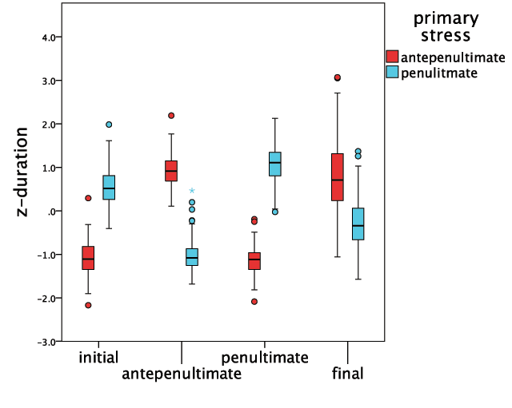

[Download](https://www.journal-labphon.org/article/id/6214/file/75056/)

Figure 1

Vowel Duration depending on Word-Stress and Position within word.

The chart of box plots in Figure 1 shows a similar pattern of alternating duration for words under both stress patterns. While the primary stressed vowels show the greatest duration and are fairly similar to each other, those in penultimate position are significantly longer than those in antepenultimate (*p* = 0.002). Both primary-stressed syllables are significantly longer than all others (*p* = 0.014 stressed antepenult compared to word-final vowel under antepenultimate stress; *p* < 0.001 all other positions’ comparison to the primary-stressed vowels). Vowels from word-initial syllables under secondary stress (in penultimate-stress words) have a length similar to unstressed word-final syllables in antepenultimate-stress words; we will see, however, in Section 2.2.2 that their F1, F2 are distinct.

The three unstressed vowels from non-final syllables show a significant difference in duration between the very shortest, those from an unstressed penultimate, and the least short of the three, those from an unstressed antepenult (*p* = 0.023). In between these two are vowels from an unstressed initial syllable; these do not differ from either of the other unstressed non-final vowels (*p* ≥ 0.225).

Word-final syllables clearly exhibit final lengthening, but we find a greater level of final lengthening under antepenultimate stress (*p* < 0.001).

#### 2.2.2 Vowel quality

Both word-stress and position significantly affect F1 and F2, and the two factors show a significant interaction. This can be seen visually in Figure 2, which shows the average for each subject for each of the four positions in the two word-types in a vowel space scatterplot.

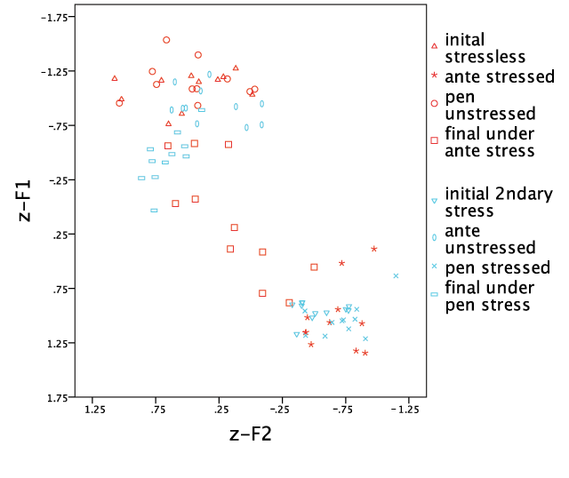

[Download](https://www.journal-labphon.org/article/id/6214/file/75057/)

Figure 2

Vowel quality depending on Word-Stress and Position; averaged by subject.

We see that the vowels from penultimate-stress words have a binary distribution, essentially falling into [ɑ] (primary and secondary stress) and [ə] (unstressed). Within the [ɑ] group from penultimate-stress words, we see vowels bearing secondary stress (from the initial syllable) showing undershoot (in the sense of Lindblom [1963] and Stevens and House [1963]) of the primary stressed vowels, and indeed they differ in both F1 (*p* = 0.020) and F2 (*p* = 0.007). Within the reduced group from penultimate-stress words, it can be seen that the averages of the word-final reduced vowels fall below (i.e., have a higher F1 than) those of non-final reduced vowels (*p* < 0.001). The two reduced vowels also differ significantly in F2 (*p* = 0.001), but it is the non-final vowel that has a lower F2, and so in that respect is less centralized.

Turning to the two non-final unstressed vowels under antepenultimate stress (from the initial and penultimate syllables), we find that they do not differ from each other (F1: *p* = 0.207; F2: *p* = 0.253).

Comparing vowels between the two stress patterns, we find that those from the two primary-stressed syllables do not vary significantly in either F1(*p* = 0.475) or F2 (*p* = 0.712). However, the two word-final vowels show a significant difference in F1 (*p* < 0.001) and F2 (*p* < 0.001). We also find a significant difference in F1 between the two unstressed vowels from non-edge syllables (F1: *p* < 0.001; F2: *p* = 0.051), where an unstressed penultimate vowel under antepenultimate stress is more centralized, having a lower F1 and a higher (although not significantly so) F2.

### 2.3 Production experiment summary and discussion

We find several differences of note between the pronunciation of vowels from non-initial syllables in the two different stress patterns. Both the duration and F1, F2 show four levels of unstressed vowels: The shortest/most centralized are those from unstressed penultimate syllables, the next shortest/most centralized are from unstressed antepenultimate syllables; notably longer/less centralized vowels are found in word-final unstressed syllables under penultimate stress, and the longest/least centralized are found in word-final unstressed under antepenultimate stress.<sup>3</sup>

While word-final vowels from words with antepenultimate stress are significantly shorter than stressed vowels (*p* = 0.014 compared to a stressed antepenult; *p* < 0.001 compared to a stressed penult), they are notably long, closer to the duration of stressed vowels than to other unstressed vowels. This might raise the concern that, despite discarding the data from speakers who seemed to place secondary stress on the final syllable in the antepenultimate-stress words, there was some degree of secondary stress on word-final vowels in these words. However, we see that the F1 and F2 of word-final vowels from words with antepenultimate stress were notably different from both those of stressed vowels and also from the case of actual secondary stress: Vowels from word-initial syllables from penultimate-stress words (F1, F2: *p* < 0.001 compared to initial vowels under secondary stress).

In both duration and vowel quality, we see a significant difference between word-final unstressed vowels coming from words with antepenultimate versus penultimate primary stress. Further, we again see a difference in both duration and vowel quality between vowels from non-edge unstressed syllables based on the stress pattern. The averages of the subjects’ averages are shown in Figure 3.

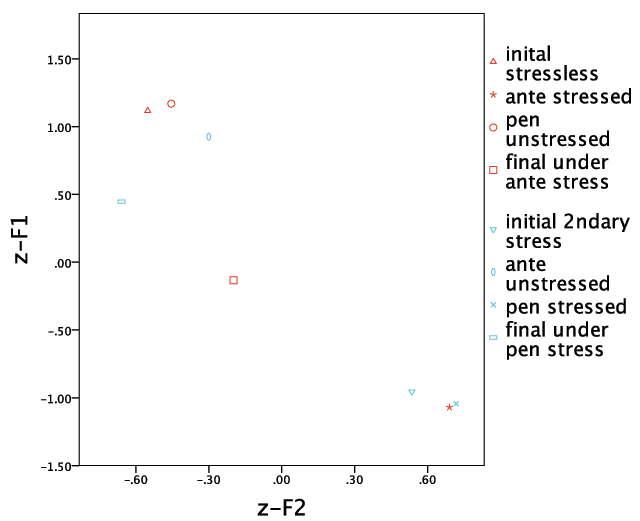

[Download](https://www.journal-labphon.org/article/id/6214/file/75058/)

Figure 3

Vowel quality depending on Word-Stress and Position; averaged over subjects.

The two unstressed vowels from penultimate-stress words are closer in quality (as well as in duration) than the unstressed vowels from non-edge and word-final syllables from antepenultimate-stress words are. Thus, the difference between a non-final unstressed vowel and a word-final unstressed vowel is accentuated in the antepenultimate-stress words (the red circle and square in Figure 3); that is, the vowel of the final syllable is much less reduced while the vowel of the non-edge unstressed syllable is more centralized, compared with word-final and non-final unstressed vowels from penultimate-stress words (the blue oval and rectangle in Figure 3).

The hypothesis put forward here, that a phonetic rhythm continues through the two unstressed syllables in the antepenultimate-primary-stress pattern, explains the differences between the sets of vowels from words with antepenultimate and those with penultimate primary stress. Under both stress patterns, non-final unstressed vowels are naturally reduced and word-final unstressed vowels are naturally longer and less reduced. We see here that an unstressed vowel in a penult, coming after antepenultimate stress, is further reduced, and an unstressed vowel in a following word-final syllable is even longer and even less reduced than would otherwise be found in word-final position. Both the enhanced phonetic weakness of the penult and the enhanced phonetic strength of the final vowel contribute to the rhythm of the word, while actually occurring in a stress lapse. As noted by a reviewer of this paper, this brings the phonetics of the final vowel very close to something like phonological stress. I am assuming that there is a meaningful difference between metric, phonological stress (which, in Optimality Theory [Prince & Smolensky, 1993] incurs some cost, such as the alignment of feet [e.g., McCarthy & Prince, 1993]), and phonetic strength. The fact that word-final syllables are found to have phonetic strength under both stress conditions shows that at least the lower level of word-final augmentation exists outside of the metrical system. The difference in duration and vowel quality between word-final vowels under antepenultimate stress and those under penultimate stress is less than is found between initial-syllable vowels that are unstressed and those that bear secondary stress. It is therefore more plausible to take the phonetic strength of word-final vowels under antepenultimate stress as a variation of the phonetic effect of final lengthening found in all final syllables.

The findings of the differences among non-final vowels and among word-final vowels leads to the question of whether one or both of these differences is perceptually consequential.

## 3. Perception experiment

The production experiment described in Section 2 found four levels of duration and vowel reduction in unstressed non-initial syllables. The vowels that occurred as part of a stress lapse showed a greater difference in duration and F1, F2 than vowels from the equivalent (but non-adjacent) unstressed syllables that were part of an alternating stress pattern. The hypothesis is the phonetic duration and less reduced vowel quality due to final lengthening can contribute to the perception of continued alternation in the case of final stress lapse, while not interrupting the rhythm when there is no final stress lapse. The production experiment found that the presence or absence of a final stress lapse correlates both with different average durations of vowels in word-final syllables, and also with different average durations of the word-internal unstressed vowel. While the vowel of a final syllable was longer under stress lapse, the vowel of the penultimate syllable was shorter under stress lapse (compared to an unstressed vowel in antepenultimate position in a word without final stress lapse). These same relative differences were found to extend to the degree of centralization of the vowels of non-edge unstressed syllables as well.

While the production study results support the hypothesis that final lapse still shows a phonetic-level alternation, we need a perception study to investigate whether this alternation is perceptible and, if so, to what degree the various factors contribute. Following Lunden (to appear), a stressed and an unstressed syllable were copied into five-syllable strings in either an alternating pattern or a non-alternating one with stress lapse (two adjacent unstressed syllables) or stress clash (two adjacent stressed syllables) either initially or finally. Five-syllable strings were chosen because this is the minimum number needed to set up a true rhythm (i.e., at least two stresses per string) in all versions of the stimuli. Test strings were made by putting syllables originally produced as unstressed word-initially or word-finally in a position to potentially work as part of the rhythmic pattern (perceptually cause stress lapse) or to interrupt the rhythmic pattern (cause the perception of stress clash). We want to test the effect of word-final syllables not only under stress lapse, where they might contribute to the rhythm, but also in strings with a penultimate stressed syllable, where the potential for these word-final syllables for interrupting rhythmic stress can also be assessed. While the focus is the effect of the syllables originally produced in word-final position, test syllables from initial position were also used in order to demonstrate that any initial strengthening effects (e.g., Fougeron & Keating, 1997) that might be present cannot contribute to a rhythmic pattern under stress lapse in the way that word-final syllables can. Having syllable strings with initial stress lapse, stress clash, and initial test syllables also forces subjects not to become hyper-focused on only the ending of the syllable strings.

### 3.1 Methods

#### 3.1.1 Participants

The participants were 56 native English speakers with reported normal hearing (male = 25, aged 18–22, average age 19.0). All were undergraduates of the College of William & Mary and received participation pool credit. None had been subjects in the production study.